# Survival analysis project

DC, RD, RL, RR

2023-07-07

# 1/ENVIRONMENT PREPARATION

First, let’s install the libraries that will be required in our analysis

```r
library(tidyverse)
#library(broom)
library(dplyr)
library(survival)
library(lubridate)
```

# 2/DATA PREPARATION

First, we need to specify the path where the dataset is located. You need to amend in with your own path

```r
setwd ('C:/Users/romai/Documents/DSTI/21-Survival Analysis/UTMB')
data_utmb17 <- read_csv("utmb_2017.csv", col_names = TRUE)
```

```
## ──────────────────────────────────────────────────────── Delimiter: "," chr
## (4): name, team, category, nationality dbl (3): ...1, bib, rank time (26):
## time, timediff, Delevret, St-Gervais, Contamines, La Balme, Bonho...
```

```r
head(data_utmb17)
```

```
## # A tibble: 6 × 33
##    ...1   bib name        team  categ…¹  rank natio…² time     timediff Delevret
##   <dbl> <dbl> <chr>       <chr> <chr>   <dbl> <chr>   <time>   <time>   <time>
## 1     0     4 D'HAENE Fr… Salo… SE H        1 FR      19:01:54 00:00:00 01:11:50
## 2     1     2 JORNET BUR… Salo… SE H        2 ES      19:16:59 00:15:05 01:10:00
## 3     2    14 TOLLEFSON … Hoka  SE H        3 US      19:53:00 00:51:06 01:15:24
## 4     3     7 THEVENARD … Asics SE H        4 FR      20:03:39 01:01:45 01:11:51
## 5     4     1 WALMSLEY J… Hoka  SE H        5 US      20:11:38 01:09:44 01:09:59
## 6     5    17 CAPELL Pau  The … SE H        6 ES      20:12:43 01:10:49 01:13:16
## # … with 23 more variables: `St-Gervais` <time>, Contamines <time>,
## #   `La Balme` <time>, Bonhomme <time>, Chapieux <time>, `Col Seigne` <time>,
## #   `Lac Combal` <time>, `Mt-Favre` <time>, Checruit <time>, Courmayeur <time>,
## #   Bertone <time>, Bonatti <time>, Arnouvaz <time>, `Col Ferret` <time>,
## #   `La Fouly` <time>, `Champex La` <time>, `La Giète` <time>, Trient <time>,
## #   `Les Tseppe` <time>, Vallorcine <time>, `Col Montet` <time>,
## #   Flégère <time>, Arrivée <time>, and abbreviated variable names ¹category, …
```

Let’s check if we get some problems during the data import

```r
problems(data_utmb17)
```

```
## # A tibble: 0 × 5
## # … with 5 variables: row <int>, col <int>, expected <chr>, actual <chr>,
## #   file <chr>
```

Let’s have a quick look on the dataset. What are the columns?

```r
colnames(data_utmb17)
```

```
##  [1] "...1"        "bib"         "name"        "team"        "category"
##  [6] "rank"        "nationality" "time"        "timediff"    "Delevret"
## [11] "St-Gervais"  "Contamines"  "La Balme"    "Bonhomme"    "Chapieux"
## [16] "Col Seigne"  "Lac Combal"  "Mt-Favre"    "Checruit"    "Courmayeur"
## [21] "Bertone"     "Bonatti"     "Arnouvaz"    "Col Ferret"  "La Fouly"
## [26] "Champex La"  "La Giète"    "Trient"      "Les Tseppe"  "Vallorcine"
## [31] "Col Montet"  "Flégère"     "Arrivée"
```

Let’s get a bit more details on columns (type, etc)

```r
str(data_utmb17)
```

```
## spec_tbl_df [2,535 × 33] (S3: spec_tbl_df/tbl_df/tbl/data.frame)
##  $ ...1       : num [1:2535] 0 1 2 3 4 5 6 7 8 9 ...
##  $ bib        : num [1:2535] 4 2 14 7 1 17 9 13 8 32 ...
##  $ name       : chr [1:2535] "D'HAENE François" "JORNET BURGADA Kilian" "TOLLEFSON Tim" "THEVENARD Xavier" ...
##  $ team       : chr [1:2535] "Salomon" "Salomon" "Hoka" "Asics" ...
##  $ category   : chr [1:2535] "SE H" "SE H" "SE H" "SE H" ...
##  $ rank       : num [1:2535] 1 2 3 4 5 6 7 8 9 10 ...
##  $ nationality: chr [1:2535] "FR" "ES" "US" "FR" ...
##  $ time       : 'hms' num [1:2535] 19:01:54 19:16:59 19:53:00 20:03:39 ...
##   ..- attr(*, "units")= chr "secs"
##  $ timediff   : 'hms' num [1:2535] 00:00:00 00:15:05 00:51:06 01:01:45 ...
##   ..- attr(*, "units")= chr "secs"
##  $ Delevret   : 'hms' num [1:2535] 01:11:50 01:10:00 01:15:24 01:11:51 ...
##   ..- attr(*, "units")= chr "secs"
##  $ St-Gervais : 'hms' num [1:2535] 01:45:05 01:44:21 01:48:38 01:45:08 ...
##   ..- attr(*, "units")= chr "secs"
##  $ Contamines : 'hms' num [1:2535] 02:41:09 02:41:01 02:45:17 02:41:11 ...
##   ..- attr(*, "units")= chr "secs"
##  $ La Balme   : 'hms' num [1:2535] 03:33:40 03:33:45 03:41:50 03:33:45 ...
##   ..- attr(*, "units")= chr "secs"
##  $ Bonhomme   : 'hms' num [1:2535] 04:28:07 04:29:18 04:41:04 04:38:06 ...
##   ..- attr(*, "units")= chr "secs"
##  $ Chapieux   : 'hms' num [1:2535] 04:53:31 04:54:39 05:10:05 05:07:23 ...
##   ..- attr(*, "units")= chr "secs"
##  $ Col Seigne : 'hms' num [1:2535] 06:18:02 06:18:04 06:40:51 06:41:10 ...
##   ..- attr(*, "units")= chr "secs"
##  $ Lac Combal : 'hms' num [1:2535] 06:37:51 06:37:54 07:02:40 07:04:45 ...
##   ..- attr(*, "units")= chr "secs"
##  $ Mt-Favre   : 'hms' num [1:2535] 07:15:35 07:15:37 07:42:45 07:45:38 ...
##   ..- attr(*, "units")= chr "secs"
##  $ Checruit   : 'hms' num [1:2535] 07:39:09 07:39:16 08:08:05 08:11:11 ...
##   ..- attr(*, "units")= chr "secs"
##  $ Courmayeur : 'hms' num [1:2535] 08:02:18 08:02:49 08:33:53 08:37:54 ...
##   ..- attr(*, "units")= chr "secs"
##  $ Bertone    : 'hms' num [1:2535] 08:54:29 08:57:30 09:29:48 09:38:22 ...
##   ..- attr(*, "units")= chr "secs"
##  $ Bonatti    : 'hms' num [1:2535] 09:44:00 09:48:28 10:21:27 10:31:58 ...
##   ..- attr(*, "units")= chr "secs"
##  $ Arnouvaz   : 'hms' num [1:2535] 10:17:44 10:23:53 10:55:21 11:09:38 ...
##   ..- attr(*, "units")= chr "secs"
```

[output cut: 42 more lines]

```
##   ..   Bertone = col_time(format = ""),
##   ..   Bonatti = col_time(format = ""),
##   ..   Arnouvaz = col_time(format = ""),
##   ..   `Col Ferret` = col_time(format = ""),
##   ..   `La Fouly` = col_time(format = ""),
##   ..   `Champex La` = col_time(format = ""),
##   ..   `La Giète` = col_time(format = ""),
##   ..   Trient = col_time(format = ""),
##   ..   `Les Tseppe` = col_time(format = ""),
##   ..   Vallorcine = col_time(format = ""),
##   ..   `Col Montet` = col_time(format = ""),
##   ..   Flégère = col_time(format = ""),
##   ..   Arrivée = col_time(format = "")
##   .. )
##  - attr(*, "problems")=<externalptr>
```

First column seems useless (it looks like a row numbering)

```r
data_utmb17 <- data_utmb17[,-1]
```

We can see that column (category) contains 2 interesting information: age category and gender. Therefore, we can create 2 new columns for gender & age In addition, we add a column “status” (1 = finisher; 0 = DNF / did not finish) based on the presence or not of a time in the column “Arrivée”

```r
data_utmb17 <-data_utmb17 |>
  mutate(gender = case_when(
    endsWith(category, " H") ~ "Male",
    endsWith(category, " F") ~ "Female"),
    age = substring(data_utmb17$category, first=1, last=2),
    status = case_when(time != 'NA' ~ 1, TRUE ~ 0),
    .after ="category")
```

We can observe that there is no column capturing the latest/highest time for all individuals. Column “Arrivée” (Arrival <=> finish line) capture only finisher (status =1). Non-finisher individuals (status = 0) have only the last time corresponding to the time where they stop the race. Therefore, we create a new column a new column “HighestTime” to capture the information about the time-to-event regardless the status.

```r
data_utmb17$highesttime <- apply(data_utmb17[11:35], 1, function(x) max(x, na.rm = TRUE))
data_utmb17<-data_utmb17|>
  mutate(highesttime = replace_na(highesttime, '00:00:00'))
```

Format of the newly-created column “highesttime” is character preventing to apply survival analysis.

```r
str(data_utmb17$highesttime)
```

```
##  chr [1:2535] "19:01:54" "19:16:59" "19:53:00" "20:03:39" "20:11:38" ...
```

Therefore, we convert it in time format (expressed in seconds) creating a the final time column “timetoevent’

```r
data_utmb17$timetoevent<- lubridate::hms(data_utmb17$highesttime)
data_utmb17$timetoevent<- period_to_seconds(data_utmb17$timetoevent)
```

Then, we remove all intermediate checkpoints time that are not useful anymore for our analysis

```r
data_utmb17<- data_utmb17[,-11:-34]
colnames(data_utmb17)
```

```
##  [1] "bib"         "name"        "team"        "category"    "gender"
##  [6] "age"         "status"      "rank"        "nationality" "time"
## [11] "Arrivée"     "highesttime" "timetoevent"
```

```r
data_utmb17<-  data_utmb17[,-c(2,3,4,8,9,10)]
```

Then, we convert the age category (SE, V1, V2, V3, V4) in age range (in years) using the international age ranking for running trail

```r
age_range <- tibble('age' =
                      c("V1", "V2","V3", "V4", "SE"),
                    'age_range' = c("40-49", "50-59", "60-69", "70+", "23-39")
                    )
data_utmb17 <- data_utmb17 |> inner_join(age_range,by = "age")

#Move column "age_range" just after column "age"
data_utmb17 <- data_utmb17  %>% relocate("age_range", .after = "age")
```

```r
table(data_utmb17$age_range)
```

```
##
## 23-39 40-49 50-59 60-69   70+
##   853  1144   472    58     5
```

The oldest category contains very few individuals (only 5 with age over 70). We could merge the 2 oldest range together.

```r
data_utmb17 ["age_range"] [data_utmb17 ["age_range"] == "60-69"]<- "60+"
data_utmb17 ["age_range"] [data_utmb17 ["age_range"] == "70+"]<- "60+"
```

```r
table(data_utmb17$age_range)
```

```
##
## 23-39 40-49 50-59   60+
##   853  1144   472    63
```

We still see that oldest groups (50-59 and 60+) contains few individuals so we decide to regroup them to have more homogeneous groups

```r
data_utmb17 ["age_range"] [data_utmb17 ["age_range"] == "50-59"] <- "50+"
data_utmb17 ["age_range"] [data_utmb17 ["age_range"] == "60+"]<- "50+"
table(data_utmb17$age_range)
```

```
##
## 23-39 40-49   50+
##   853  1144   535
```

```r
table(data_utmb17$age_range, data_utmb17$gender)
```

```
##
##         Female Male
##   23-39     95  758
##   40-49    108 1036
##   50+       39  496
```

# 3/SURVIVAL ANALYSIS

## a/Global analysis

### Kaplan-Meier

```r
fit.KM <- survfit(Surv(timetoevent, status) ~ 1, data = data_utmb17)
summary(fit.KM)
```

```
## Call: survfit(formula = Surv(timetoevent, status) ~ 1, data = data_utmb17)
##
##    time n.risk n.event survival  std.err lower 95% CI upper 95% CI
##   68514   2134       1 0.999531 0.000468     9.99e-01      1.00000
##   69419   2128       1 0.999062 0.000663     9.98e-01      1.00000
##   71580   2114       1 0.998589 0.000814     9.97e-01      1.00000
##   72219   2106       1 0.998115 0.000942     9.96e-01      0.99996
##   72698   2102       1 0.997640 0.001054     9.96e-01      0.99971
##   72763   2101       1 0.997165 0.001156     9.95e-01      0.99943
##   73188   2095       1 0.996689 0.001249     9.94e-01      0.99914
##   77059   2072       1 0.996208 0.001338     9.94e-01      0.99883
##   77312   2069       1 0.995727 0.001421     9.93e-01      0.99852
##   78271   2062       1 0.995244 0.001501     9.92e-01      0.99819
##   78947   2053       1 0.994759 0.001576     9.92e-01      0.99785
##   79232   2048       1 0.994273 0.001649     9.91e-01      0.99751
```

[output cut: 1607 more lines]

```r
fit.KM
```

```
## Call: survfit(formula = Surv(timetoevent, status) ~ 1, data = data_utmb17)
##
##         n events median 0.95LCL 0.95UCL
## [1,] 2532   1684 147471  146205  148641
```

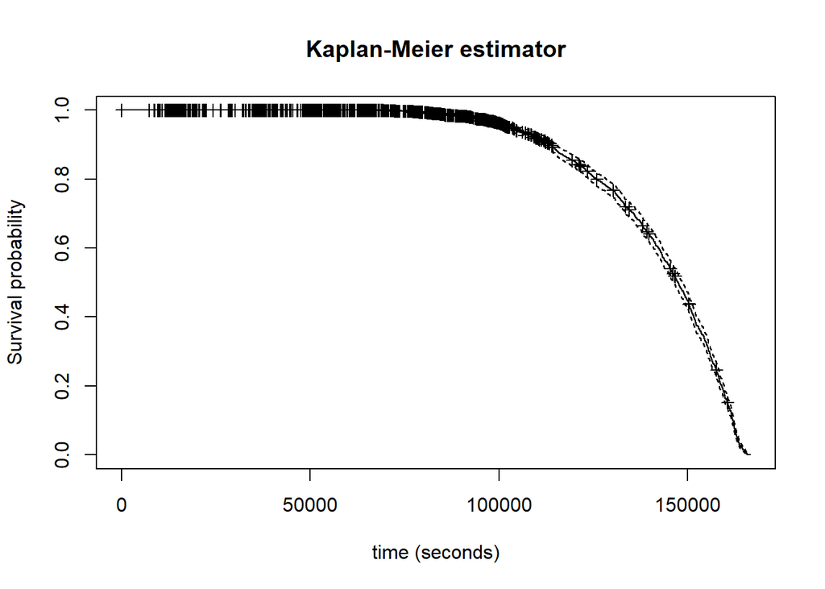

```r
plot(fit.KM, mark.time = TRUE,
     main = "Kaplan-Meier estimator",
     ylab = "Survival probability",
     xlab = "time (seconds)")
```

## b/ Group by AGE

### Kaplan-Meier

```r
fit.KMage <- survfit(Surv(timetoevent, status) ~ age_range, data = data_utmb17)
fit.KMage
```

```
## Call: survfit(formula = Surv(timetoevent, status) ~ age_range, data = data_utmb17)
##
##                    n events median 0.95LCL 0.95UCL
## age_range=23-39  853    645 142474  139378  144144
## age_range=40-49 1144    771 148863  147408  150204
## age_range=50+    535    268 153591  151397  155904
```

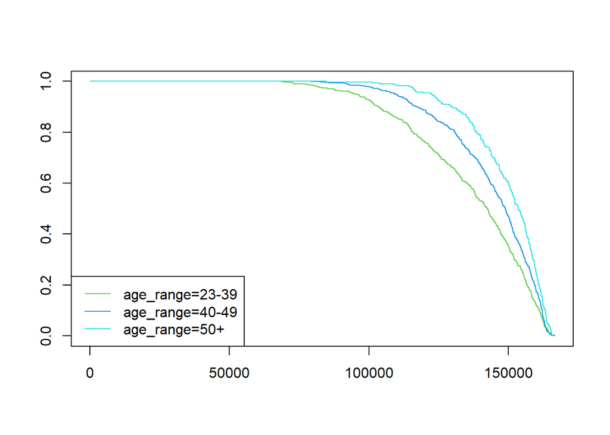

```r
plot(fit.KMage, col = 3:8)
legend("bottomleft", lty = 1, col = 3:8, legend = names(fit.KMage$strata))
```

### Log rank test

The logrank test is the most widely used method of comparing two or more survival curves

```r
diff.KMage <- survdiff(Surv(timetoevent, status) ~ age_range, data = data_utmb17)
diff.KMage
```

```
## Call:
## survdiff(formula = Surv(timetoevent, status) ~ age_range, data = data_utmb17)
##
##                    N Observed Expected (O-E)^2/E (O-E)^2/V
## age_range=23-39  853      645      529    25.374      37.2
## age_range=40-49 1144      771      791     0.526       1.0
## age_range=50+    535      268      363    25.072      32.3
##
##  Chisq= 51.4  on 2 degrees of freedom, p= 7e-12
```

p-value = 7e-12 (<<0.05), we reject H0 => there exists at least a significant difference between 2 age range reinforcing the visual impression of a trend towards better survival (chance to finish the race) when the age is less advanced.

[figure not shown]

As we can see on the KM curve, both curves are crossing twice. We can suspect an influence of the age. Let’s now stratify on the age to see of we can observe a difference between gender

### Semi-parametric Cox regression

```r
cox.gender<- coxph(Surv(timetoevent, status) ~ gender + strata(age_range), data = data_utmb17)
summary(cox.gender)
```

```
## Call:
## coxph(formula = Surv(timetoevent, status) ~ gender + strata(age_range),
##     data = data_utmb17)
##
##   n= 2532, number of events= 1684
##
##               coef exp(coef) se(coef)     z Pr(>|z|)
## genderMale 0.15658   1.16951  0.08659 1.808   0.0706 .
## ---
## Signif. codes:  0 '***' 0.001 '**' 0.01 '*' 0.05 '.' 0.1 ' ' 1
##
##            exp(coef) exp(-coef) lower .95 upper .95
## genderMale      1.17     0.8551     0.987     1.386
##
## Concordance= 0.508  (se = 0.004 )
## Likelihood ratio test= 3.41  on 1 df,   p=0.06
## Wald test            = 3.27  on 1 df,   p=0.07
## Score (logrank) test = 3.28  on 1 df,   p=0.07
```

## d/ Group by Age AND Gender

### Kaplan-Meier

```r
fit.KMage_gender <- survfit(Surv(timetoevent, status) ~ age_range + gender, data = data_utmb17)
fit.KMage_gender
```

```
## Call: survfit(formula = Surv(timetoevent, status) ~ age_range + gender,
##     data = data_utmb17)
##
##                                   n events median 0.95LCL 0.95UCL
## age_range=23-39, gender=Female   95     66 141317  138019  149719
## age_range=23-39, gender=Male    758    579 142665  138688  144246
## age_range=40-49, gender=Female  108     61 154429  150636  158749
## age_range=40-49, gender=Male   1036    710 148005  146380  149735
## age_range=50+, gender=Female     39     20 156299  149696  163332
## age_range=50+, gender=Male      496    248 153310  151395  155904
```

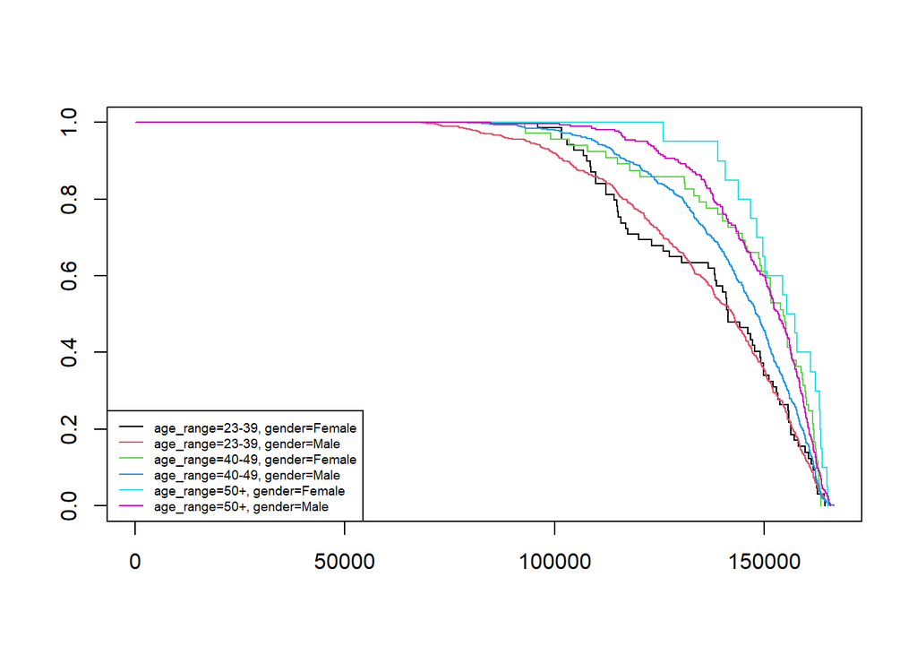

```r
plot(fit.KMage_gender, col = 1:9)
legend("bottomleft",lty = 1, col = 1:9, legend = names(fit.KMage_gender$strata), cex= 0.6, box.lty=1)
```

### Log rank test

```r
diff.KMage_gender1 <- survdiff(Surv(timetoevent, status) ~ gender + age_range , data = data_utmb17)
diff.KMage_gender1
```

```
## Call:
## survdiff(formula = Surv(timetoevent, status) ~ gender + age_range,
##     data = data_utmb17)
##
##                                   N Observed Expected (O-E)^2/E (O-E)^2/V
## gender=Female, age_range=23-39   95       66     54.2    2.5854     2.675
## gender=Female, age_range=40-49  108       61     76.9    3.2996     3.472
## gender=Female, age_range=50+     39       20     36.1    7.2044     7.417
## gender=Male, age_range=23-39    758      579    475.0   22.7890    31.954
## gender=Male, age_range=40-49   1036      710    714.5    0.0281     0.049
## gender=Male, age_range=50+      496      248    327.3   19.2240    24.011
##
##  Chisq= 55.7  on 5 degrees of freedom, p= 1e-10
```

### Semi-parametric Cox regression

with interaction btw age and sex age:gender

```r
cox.age_gender<- coxph(Surv(timetoevent, status) ~ gender + age_range + age_range:gender, data = data_utmb17)
summary(cox.age_gender)
```

```
## Call:
## coxph(formula = Surv(timetoevent, status) ~ gender + age_range +
##     age_range:gender, data = data_utmb17)
##
##   n= 2532, number of events= 1684
##
##                                coef exp(coef)  se(coef)      z Pr(>|z|)
## genderMale                 0.001039  1.001040  0.130026  0.008   0.9936
## age_range40-49            -0.432995  0.648564  0.177780 -2.436   0.0149 *
## age_range50+              -0.798129  0.450170  0.255725 -3.121   0.0018 **
## genderMale:age_range40-49  0.227239  1.255129  0.186348  1.219   0.2227
## genderMale:age_range50+    0.318719  1.375365  0.266579  1.196   0.2319
## ---
## Signif. codes:  0 '***' 0.001 '**' 0.01 '*' 0.05 '.' 0.1 ' ' 1
##
##                           exp(coef) exp(-coef) lower .95 upper .95
## genderMale                   1.0010     0.9990    0.7758    1.2916
## age_range40-49               0.6486     1.5419    0.4577    0.9189
## age_range50+                 0.4502     2.2214    0.2727    0.7431
## genderMale:age_range40-49    1.2551     0.7967    0.8711    1.8085
## genderMale:age_range50+      1.3754     0.7271    0.8157    2.3192
##
## Concordance= 0.576  (se = 0.008 )
## Likelihood ratio test= 57.42  on 5 df,   p=4e-11
## Wald test            = 54.75  on 5 df,   p=1e-10
## Score (logrank) test = 55.66  on 5 df,   p=1e-10
```